# COMP41680 Assignment-01: Data Collection & Preparation

#### Author: Shyam Mohan Kizhakekara

#### Student No.: 17200802

#### Email Id: shyam.kizhakekara@ucdconnect.ie

#### Date of Submission: 26 Mar 2018

## Introduction

**The objective of this assignment is to collect a dataset from one or more open web APIs and use Python to pre-process and analyse the collected data. In this project, we collect, pre-process and analyze the data related to movies. The data is extracted using multiple web-APIs, and pre-processed and analyzed using the python pandas framework.**

```python
#Import all the relevant packages required
from IPython.display import display
import csv, json, os, time
import urllib.request
import pandas as pd
```

## [1.] Selection of Relevant Web-APIs

**We have used four web-APIs in this project.**

**(a) TMDb API - https://developers.themoviedb.org/3/getting-started/introduction**

- **This is the official API of the The Movie Database (TMDb). For the freely available version, an API key is required, which is provided upon signup and a small amount of rate limiting is enforced. The current limits are 40 requests every 10 seconds and are limited by IP address, not API key. The only format supported by this API is JSON.**

**(b) OMDb API - http://www.omdbapi.com/**

- **Although unofficial, the OMDb (The Open Movie Database) API is a RESTful web service to obtain movie information from IMDb. An API key is provided after signup, to fetch the movie data and it supports both XML and JSON formats. In our case, we have used the JSON format. For the free version, the rate limit is 1000 requests per day.**

**(c) Tweepy Standard Search - https://developer.twitter.com/en/docs/tweets/search/api-reference/get-search-tweets.html**

- **The wrapper for official Twitter API (RESTful web service), to search for a specific term and extract a certain number of tweets about it from twitter. Four API keys are required to use this API and extract tweets, and is provided only if the user has a valid twitter account. The API supports multiple formats, but we have chosen to use JSON format in our project. Rate limiting of the API is primarily on a per-user basis — or more accurately described, per user access token. When using application-only authentication, rate limits are determined globally for the entire application.**

**(d) AYLIEN Sentiment Analysis API - http://docs.aylien.com/textapi/#using-the-api**

- **AYLIEN API is effective in bringing the power of Natural Language Processing to textual content, in our case, tweets. Using this API, we can detect the sentiment of a document, in terms of its polarity ("positive" or "negative" or "neutral") and subjectivity ("subjective" or "objective"). An application key and ID are required to extract the sentiments using this API and would be provided only upon signing up. The API returns both XML and JSON, and we use JSON. Rate limiting of this API is 1000 calls per day and 120 calls per minute.**

**_Before execution of this notebook, kindly ensure that the packages for Tweepy and Aylien APIs are installed on the machine. This is because we have used wrapper packages of the actual web-APIs in this project. To install the packages, use the following commands from a prompt (anaconda prompt)._**

- **pip install tweepy**
- **pip install aylien-apiclient**

```python
# Define the API key for TMDb and also form the request URLs to fetch the movie data
tmdb_api_key = "293f140b36551ab89a84993fc7131ea8"
tmdb_latest_movie_url = "https://api.themoviedb.org/3/movie/popular?api_key="+tmdb_api_key+"&language=en-US&page="
tmdb_get_imdb_id_url_head = "https://api.themoviedb.org/3/movie/"
tmdb_get_imdb_id_url_tail = "/external_ids?api_key="+tmdb_api_key

# Define the API key for OMDb and also form the request URL to fetch the movie data
omdb_api_key="4fc3b96e"
omdb_get_movie_details_url_head = "http://www.omdbapi.com/?i="
omdb_get_movie_details_url_tail = "&apikey="+omdb_api_key
```

```python
# Import the packages for Tweepy & Aylien APIs
import tweepy
from aylienapiclient import textapi

# Define the API access credentials for Tweepy and initialize an instance of the same
tw_consumer_key = 'tRlTPsz9LPnCW46udYfHNvjBN'
tw_consumer_secret = 'FNyx08cnibSV5Vg0SzBbDI3xzrxTHGepVlqXZtF7oXwHTzN1gi'
tw_access_token = '1497884474-AqPlLZ5hKIQCdRYJKiCCoBSLappkvHeDJDZDl2A'
tw_access_token_secret = 'E8LIYyZsSN2TYs41vPiZuxELBTGMI4YKA8elg2DpjhHnp'
tw_auth = tweepy.OAuthHandler(tw_consumer_key, tw_consumer_secret)
tw_auth.set_access_token(tw_access_token, tw_access_token_secret)
tw_api = tweepy.API(tw_auth, parser=tweepy.parsers.JSONParser())

# Define the API access credentials for AYLIEN and initialize a new client of the same
ay_consumer_key = 'f8cf27dd'
ay_consumer_secret = '757c31078a25428c28597d87b46bb80c'
ay_client = textapi.Client(ay_consumer_key, ay_consumer_secret)
```

**Now that we have chosen the respective web-APIs, we will use them to extract the details of different movies to form our dataset for analysis.**

## [2.] Data Collection using Web-APIs

**First, define a generic function that takes in a URL (API URL request) as an argument, sends the request to the database and retrieves the data. As mentioned earlier, in our project, all the APIs return the data in JSON format. This function returns the JSON object containing the relevant data.**

```python
# Function to fetch the data in a JSON format,using the url passed to it
def getApiURLJsonData(url):
    response = urllib.request.urlopen(url)
    raw_json = response.read().decode('utf-8')
    movie_json = json.loads(raw_json)
    return movie_json
```

**The TMDb API does not return the IMDb ID of the movies, along with the other details. The IMDb ID of the corresponding movie has to be retrieved using a different end-point of the same API. A function is defined below, that returns the IMDb ID of the corresponding movie, by accepting the TMDb ID of the movie as a parameter.**

```python
# Function to retrieve the IMDb ID of a movie
def getIMDbMovieID(tmdb_id):
    tmdb_get_imdb_id_url=tmdb_get_imdb_id_url_head+str(tmdb_id)+tmdb_get_imdb_id_url_tail
    tmdb_external_id_json = getApiURLJsonData(tmdb_get_imdb_id_url)
    imdb_id = tmdb_external_id_json['imdb_id']
    return imdb_id
```

**The below function is to get the ID of the movie in IMDb using the TMDb ID of the movie passed as first parameter, and then use this ID with the OMDb API to retrieve the values for the list of parameters passed as the second argument. It returns a list of values corresponding to the parameters.**

```python
# Function to get all the required details of a movie from IMDb.
def getIMDbMovieDetails(tmdb_id, imdbParamList):
    imdb_details_list = []
    # Retrieve the id of the movie in IMDb
    imdb_id =  getIMDbMovieID(tmdb_id)
    if(imdb_id is None):
        # If no IMDb ID is obtained (or it is of None type), then set 'N/A' as the default value for all the parameters.
        for param in imdbParamList:
            imdb_details_list.append("N/A")
    else:
        # Form the URL, fetch the details of the movie from IMDb and append them to the list.
        omdb_get_movie_details_url = omdb_get_movie_details_url_head+imdb_id+omdb_get_movie_details_url_tail
        imdb_details_json = getApiURLJsonData(omdb_get_movie_details_url)
        if(imdb_details_json['Response']=="True"):
            for param in imdbParamList:
                imdb_details_list.append(imdb_details_json[param])
        else:
            for param in imdbParamList:
                imdb_details_list.append("N/A")

    return imdb_details_list
```

**For every movie, certain details associated with it are fetched from TMDb (using TMDb API) and certain other details from IMDb (using OMDb API). The following function is to fetch the details of a movie from the TMDb and also invoke the other functions to retrieve the corresponding details from IMDb.**

```python
# Function to fetch all the relevant movie details from TMDb API.
def getMovieParamData(movie_data, movieParamList, imdbParamList):
    movieDataList=[]
    for param in movieParamList:
        if(param=='id'):
            # If the parameter is id, then use it to get the IMDb ID and other details from IMDB.
            movieDataList.append(movie_data[param])
            imdb_details_list = getIMDbMovieDetails(movie_data[param], imdbParamList)
            movieDataList[2:1] = imdb_details_list
        else:
            # Append all values to a list
            movieDataList.append(movie_data[param])
    return movieDataList
```

**The following function is to determine the sentiment contained in a tweet extracted from twitter, about a specific movie. It takes in a single argument, the full text of the tweet and returns the sentiment.**

```python
# Function to analyze the tweet and determine the sentiment using AYLIEN API.
def findTweetSentiment(tweetContent):
    sentimentPolarity=""

    # Remove extra spaces or newlines around the text and use 'utf-8' encoding
    tweetContent = tweetContent.encode('utf-8').strip()

    # Reject tweets which are empty
    if len(tweetContent) != 0:
        # Invoke the AYLIEN Text API
        sentiment = ay_client.Sentiment({'mode':'tweet', 'text': tweetContent})
        # Get the polarity/nature of the sentiment conveyed by the tweet
        sentimentPolarity = sentiment['polarity']
    return sentimentPolarity
```

**Below is the function to extract a certain number of tweets about a movie(s). It takes in four parameters namely, the search term (for searching in twitter), a JSON object containing all the details of a specific tweet on the search term, the name of the CSV file to write the data to, and the list of paramters for which the corresponding values have to be retrieved from the JSON object. The function combines all the required data into a list and writes it as a row to the CSV file.**

```python
# Function to extract the values for the required parameters from the tweet using Tweepy and write output to the CSV file
def getAndWriteTweetData(query, status, file_name, tweetParamList):
    dataList=[]
    sentimentPolarity=""

    with open(file_name, "a", newline='', encoding='utf-8') as write_file: #open the file / create it, newline ='' to prevent blank lines being written
        f = csv.writer(write_file)
        dataList.append(query)
        # Iterate through the list of parameters and fetch the value for each of them.
        for param in tweetParamList:
            if(param=='full_text'):
                # If the value for the parameter is tweet content itself, then use AYLIEN API to determine its sentiment
                sentimentPolarity=findTweetSentiment(status[param])
                # Append the sentiment to the data list
                dataList.append(sentimentPolarity)
            else:
                dataList.append(status[param])
        # Write a row of data to the CSV file
        f.writerow(dataList)
    write_file.close()
```

**We have now completed the process of collecting the relevant data from multiple web-APIs (in JSON format). The next step is parsing them and saving them to a file for subsequent analysis.**

### [3.] Data Parsing & Storage in CSV Format

**Define a function to create a CSV file with the required headers. This function takes in a two arguments, the name of the file and the headers to be used in it. Since, we use multiple APIs, the data needs to be combined and placed at a common source, which is the CSV file. Note that we would have two CSV files generated as part of the project, one as the main source of data and the other, is used to get an entry point to the possible future enhancements of this project.**

```python
# Function to create a CSV file with the relevant headers.
def create_file (file_name, headerList):
    # Create (open) the file. The parameter newline = '', in order to prevent blank lines being written.
    with open(file_name, "w", newline='') as write_file:
        f = csv.writer(write_file)
        # Write the headers to the file
        f.writerow(headerList)
    write_file.close()
```

**Create a function to keep appending the final set of movie data identified for our analysis, to the CSV file. The function takes the file name and the list of movie data to be written to the CSV file.**

```python
# Function to append the required movie details to the CSV file.
def writeMovieData(fileName, movieDataList):
    # Open the CSV file. The parameter newline = '', in order to prevent blank lines being written.
    with open(fileName, "a", newline='', encoding='utf-8') as write_file:
        f = csv.writer(write_file)
        # Write the row of movie details identified for analysis
        f.writerow(movieDataList)
    write_file.close()
```

In the below section, we first define the name of the CSV file and invoke the function to create the same. Next, we define two separate lists of parameters to be retrieved through the TMDb and OMDb APIs, respectively. Finally, we define the number of pages to be retrieved from TMDb results (using the URL and TMDb API), iterate through each of them and form the list comprising of all values related to a particular movie. This list is then written as a single row to the CSV file.  
_At the moment we are collecting 300 movie records. To increase the amount of data retreieved, we may change the 'pageLimit' parameter accordingly_</font>.

```python
# The final CSV file with the combined data from all APIs
fileName="17200802_MovieData.csv"
# Create the CSV file
headerList = ['MovieTitle', 'Id', 'Production', 'Director', 'Runtime', 'Genre', 'Revenue', 'Rated', 'Language', 'ReleaseDate', 'Popularity', 'VoteCount', 'VoteAverage', 'Adult']
create_file(fileName, headerList)

# The list of keys in the resulting JSON file, to be retrieved from the TMDb
movieParamList = ['original_title', 'id', 'release_date', 'popularity', 'vote_count', 'vote_average', 'adult']
# The list of keys in the resulting JSON file, to be retrieved from the IMDb
imdbParamList = ['Production', 'Director', 'Runtime', 'Genre', 'BoxOffice', 'Rated', 'Language']

# Set the no. of result-pages to be retrieved through the TMDb API
pageLimit = 16
for pageNum in range(1, pageLimit):
    # Form the URL string by passing the api_key and the page number
    tmdb_latest_movies_url="https://api.themoviedb.org/3/movie/popular?api_key="+tmdb_api_key+"&language=en-US&page="+str(pageNum)
    # Get the details in JSON format
    movie_json = getApiURLJsonData(tmdb_latest_movies_url)
    # Iterate through the JSON object and fetch all the relevant movie details
    for movie_data in movie_json['results']:
        movieDataList=getMovieParamData(movie_data, movieParamList, imdbParamList)
        # Write the final list of values as one row to the CSV file
        writeMovieData(fileName, movieDataList)
        time.sleep(0.200)
```

**Here, we complete the task of parsing the data collected from different APIs and storing them at a single source(a CSV file). We now proceed to loading this data to a dataframe usind pandas and pre-processing them subsequently.**

### [4.] Loading Data to DataFrame & Applying Pre-Processing

### (a) Loading the Data into DataFrame

**Using pandas, the movie data is loaded into a dataframe, directly from the CSV file we generated before. The number of rows and columns in the dataframe, along with a few rows is displayed on the console (using 'shape').**

```python
# Create the dataframe by loading the data from the CSV file, formed earlier.
movieDetailsDataFrame = pd.read_csv(fileName, index_col='Id')

# Get the count of rows & columns in the dataframe, and display them
totalRowCount = movieDetailsDataFrame.shape[0]
totalColCount = movieDetailsDataFrame.shape[1]

# Display the no. of rows and columns in the dataframe
display("Shape of DataFrame:"+str(movieDetailsDataFrame.shape))

# Display first 3 elements of the dataframe to verify the columns and their values
movieDetailsDataFrame[0:3]
```

```
'Shape of DataFrame:(300, 13)'
```

| Id | MovieTitle | Production | Director | Runtime | Genre | Revenue | Rated | Language | ReleaseDate | Popularity | VoteCount | VoteAverage | Adult |
| --- | --- | --- | --- | --- | --- | --- | --- | --- | --- | --- | --- | --- | --- |
| 337167 | Fifty Shades Freed | Universal Pictures | James Foley | 105 min | Drama, Romance, Thriller | $95,599,460 | R | English | 2018-02-07 | 577.897054 | 1097 | 6.1 | False |
| 269149 | Zootopia | Walt Disney Animation Studios | Byron Howard, Rich Moore, Jared Bush(co-director) | 108 min | Animation, Adventure, Comedy | $341,264,012 | PG | English | 2016-02-11 | 392.335017 | 6675 | 7.7 | False |
| 284054 | Black Panther | Marvel Studios | Ryan Coogler | 134 min | Action, Adventure, Sci-Fi | $501,105,037 | PG-13 | Swahili, Nama, English, Xhosa, Korean | 2018-02-13 | 325.729722 | 3451 | 7.4 | False |

### (b) Data Pre-Processing

#### Drop the Columns that Add No Value

__Now that we have our dataframe, we must pre-process and normalize its contents to extract the best possible insights. In our first step, we take a look at all the columns and figure out which of them would actualy be useful in our analysis.__

__We can see from our dataframe that all the values in the column 'Adult' are 'False'. As such, this column is not useful in our analysis. Hence, we can drop it from the dataframe. To confirm this, we first take a count of the no. of rows in the dataframe, where the value in 'Adult' column is 'False' and then, compare it with the total rowcount of the dataframe. If both are the same, then we drop the column.__</font>

```python
# Get the count of rows in the dataframe where the value in 'Adult' column is 'False'
adultFalseValRowCount = movieDetailsDataFrame.loc[movieDetailsDataFrame['Adult'] == False]['Adult'].count()

if totalRowCount==adultFalseValRowCount:
    # Drop the 'Adult' column from the dataframe since all the values in the column are the same
    movieDetailsDataFrame = movieDetailsDataFrame.drop(['Adult'], axis=1)

# Display first few elements of the dataframe to verify the columns and their values
movieDetailsDataFrame[0:3]
```

| Id | MovieTitle | Production | Director | Runtime | Genre | Revenue | Rated | Language | ReleaseDate | Popularity | VoteCount | VoteAverage |
| --- | --- | --- | --- | --- | --- | --- | --- | --- | --- | --- | --- | --- |
| 337167 | Fifty Shades Freed | Universal Pictures | James Foley | 105 min | Drama, Romance, Thriller | $95,599,460 | R | English | 2018-02-07 | 577.897054 | 1097 | 6.1 |
| 269149 | Zootopia | Walt Disney Animation Studios | Byron Howard, Rich Moore, Jared Bush(co-director) | 108 min | Animation, Adventure, Comedy | $341,264,012 | PG | English | 2016-02-11 | 392.335017 | 6675 | 7.7 |
| 284054 | Black Panther | Marvel Studios | Ryan Coogler | 134 min | Action, Adventure, Sci-Fi | $501,105,037 | PG-13 | Swahili, Nama, English, Xhosa, Korean | 2018-02-13 | 325.729722 | 3451 | 7.4 |

__We can see above that the column 'Adult', no longer exists in the dataframe.__</font>

#### Handle Missing Values

**In the second step, we figure out all the null or empty values in our dataframe and replace them accordingly.**

```python
# Get the different columns and the no. of missing values in them.
movieDetailsDataFrame.isnull().sum()
```

```
MovieTitle      0
Production     15
Director        2
Runtime         8
Genre           2
Revenue        79
Rated          12
Language        3
ReleaseDate     0
Popularity      0
VoteCount       0
VoteAverage     0
dtype: int64
```

We can observe that, the columns 'Production', 'Director', 'Runtime', 'Genre', 'Revenue', 'Rated' & 'Language' contain missing values.  
- For the columns, 'Production', 'Director', 'Genre', we cannot set any calculated values, as these are all of type 'string'. Hence, we set a default value 'Unknown' to all the columns.  
- For the column 'Rated', we replace the missing values with one of its own values 'NOT RATED', whcih matches the situation.  
- For the column 'Language', we replace the missing values with the default value 'English'.  
- For the columns 'Runtime' & 'Revenue', we set the values '0 min' & '$0', respectively. _But these two values are temporary and would be replaced in further steps._  
In the below section we fix them as mentioned.

```python
# Replace all missing values in the columns 'Production', 'Director', 'Genre' & 'Rated'
movieDetailsDataFrame["Production"] = movieDetailsDataFrame["Production"].fillna("Unknown")
movieDetailsDataFrame["Director"] = movieDetailsDataFrame["Director"].fillna("Unknown")
movieDetailsDataFrame["Genre"] = movieDetailsDataFrame["Genre"].fillna("Unknown")
movieDetailsDataFrame["Rated"] = movieDetailsDataFrame["Rated"].fillna("NOT RATED")

# Replace all missing values in the column 'Language'
movieDetailsDataFrame["Language"] = movieDetailsDataFrame["Language"].fillna("English")

# Replace all missing values in the column 'Runtime' (temporary replacement)
movieDetailsDataFrame["Runtime"] = movieDetailsDataFrame["Runtime"].fillna("0 min")

# Replace all missing values in the column 'Revenue' (temporary replacement)
movieDetailsDataFrame["Revenue"] = movieDetailsDataFrame["Revenue"].fillna("$0")
```

#### Convert Column Types

Now let us convert the types of certain columns that are currently of type 'string'.  
- The column 'ReleaseDate', needs to be converted from string to datetime, as it contains date values.  
- Similarly, the columns 'Runtime' & 'Revenue' need to be converted from string to int and float, respectively.  
We will also rename the columns 'Runtime' & 'Revenue' accordingly, so that it is easily readable and understandable.

```python
# Convert the type of the column 'ReleaseDate' from string to datetime
movieDetailsDataFrame['ReleaseDate'] = pd.to_datetime(movieDetailsDataFrame['ReleaseDate'])

# Convert the type of the columns 'Runtime' & 'Revenue' from string to numeric
movieDetailsDataFrame['Runtime'] = movieDetailsDataFrame['Runtime'].replace('[ min]', '', regex=True)
movieDetailsDataFrame['Runtime'] = pd.to_numeric(movieDetailsDataFrame['Runtime'])
movieDetailsDataFrame['Revenue'] = movieDetailsDataFrame['Revenue'].replace('[\$,]', '', regex=True)
movieDetailsDataFrame['Revenue'] = pd.to_numeric(movieDetailsDataFrame['Revenue'])

# Rename the columns 'Runtime' & 'Revenue', for easy readability
movieDetailsDataFrame = movieDetailsDataFrame.rename(columns={'Revenue': 'Revenue($)', 'Runtime': 'Runtime(mins)'})
```

Now that we have converted the types of the columns 'Runtime' & 'Revenue' and also renamed them, let us complete the pending task of replacing the missing values in these columns. Recall that earlier, we had set temporary values in these columns.  
Since, these are numeric fields, let us calculate the mean of these two columns and then set the same as the default value for both these columns.

```python
# Calculate the mean of columns 'Runtime' & 'Revenue' and round them off accordingly.
mean_runtime = round(movieDetailsDataFrame['Runtime(mins)'].mean(), 2)
mean_revenue = round(movieDetailsDataFrame['Revenue($)'].mean(), 3)

# Now replace the temporary values set earlier, in these columns
movieDetailsDataFrame["Runtime(mins)"] = movieDetailsDataFrame["Runtime(mins)"].replace(0, mean_runtime)
movieDetailsDataFrame["Revenue($)"] = movieDetailsDataFrame["Revenue($)"].replace(0, mean_revenue)
```

#### Normalize/Scale the Numeric Values

**All the numeric values in the dataframe must be normalized or brought to the same range, for effective results to be obtained as a result of the analysis.**

__We can see that, all the values in the columns 'Runtime(mins)', 'Revenue($)', 'Popularity', 'VoteCount' & 'VoteAverage' are not in the same range. Hence, we apply min-max normalization on the values in all these columns, except 'VoteAverage'. To do this, we take the minimum and maximum values in each of these columns and, then apply the formula (val-min)/(max-min) to normalize the values.  
In case of the column 'VoteAverage', we just divide each of its values by 10, since it is already in the range of 0-10.__</font>

```python
# Normalize the values of the columns 'Runtime(mins)', 'Revenue($), 'Popularity' & 'VoteCount' using min-max normalization
movieDetailsDataFrame['Runtime(mins)'] = (movieDetailsDataFrame['Runtime(mins)'] - movieDetailsDataFrame['Runtime(mins)'].min())/(movieDetailsDataFrame['Runtime(mins)'].max() - movieDetailsDataFrame['Runtime(mins)'].min())
movieDetailsDataFrame['Revenue($)'] = (movieDetailsDataFrame['Revenue($)'] - movieDetailsDataFrame['Revenue($)'].min())/(movieDetailsDataFrame['Revenue($)'].max() - movieDetailsDataFrame['Revenue($)'].min())
movieDetailsDataFrame['Popularity'] = (movieDetailsDataFrame['Popularity'] - movieDetailsDataFrame['Popularity'].min())/(movieDetailsDataFrame['Popularity'].max() - movieDetailsDataFrame['Popularity'].min())
movieDetailsDataFrame['VoteCount'] = (movieDetailsDataFrame['VoteCount'] - movieDetailsDataFrame['VoteCount'].min())/(movieDetailsDataFrame['VoteCount'].max() - movieDetailsDataFrame['VoteCount'].min())

# Scale the values of the column 'VoteAverage' to bring it to the range(0,1)
movieDetailsDataFrame['VoteAverage'] = movieDetailsDataFrame['VoteAverage']/10
```

#### Create Any New Columns Required

**Once pre-processing is done, we will create two new columns 'ReleaseMonth' and 'ReleaseYear' from the existing 'ReleaseDate' column, which will further help our analysis using plots.**

```python
# Import the datetime package
from datetime import datetime as dt

# Create two new columns in the dataframe to represent the Month & Year of Release, respectively.
movieDetailsDataFrame['ReleaseMonth'] = movieDetailsDataFrame['ReleaseDate'].dt.strftime('%b')
movieDetailsDataFrame['ReleaseYear'] = movieDetailsDataFrame['ReleaseDate'].dt.strftime('%Y')

# Display first 3 elements of the dataframe to verify the columns and their values
movieDetailsDataFrame[0:3]
```

| Id | MovieTitle | Production | Director | Runtime(mins) | Genre | Revenue($) | Rated | Language | ReleaseDate | Popularity | VoteCount | VoteAverage | ReleaseMonth | ReleaseYear |
| --- | --- | --- | --- | --- | --- | --- | --- | --- | --- | --- | --- | --- | --- | --- |
| 337167 | Fifty Shades Freed | Universal Pictures | James Foley | 0.463687 | Drama, Romance, Thriller | 0.101934 | R | English | 2018-02-07 | 1.000000 | 0.065811 | 0.61 | Feb | 2018 |
| 269149 | Zootopia | Walt Disney Animation Studios | Byron Howard, Rich Moore, Jared Bush(co-director) | 0.480447 | Animation, Adventure, Comedy | 0.364250 | PG | English | 2016-02-11 | 0.661459 | 0.400444 | 0.77 | Feb | 2016 |
| 284054 | Black Panther | Marvel Studios | Ryan Coogler | 0.625698 | Action, Adventure, Sci-Fi | 0.534925 | PG-13 | Swahili, Nama, English, Xhosa, Korean | 2018-02-13 | 0.539943 | 0.207031 | 0.74 | Feb | 2018 |

**With this, we completed loading the data from CSV into dataframe and data pre-processing. We dropped the columns that do not add any value to the analysis, handled/replaced missing values, converted column types and normalized/scaled the numeric values.**

### [5.] Summarizing the Analysis

**We now summarize our analysis using different plots and graphical representations. All the interpretations, insights and conclusions drawn from this dataset would be brought to the table, in this section.**

#### No. of Movies Released Per Month

Our objective here, is to plot a bar graph that displays the number of movies released per month, irrespective of the year.  
We can see that most number of movies are released in _October_ closely followed by _June_. Similarly, we can also create graphs for determining the year, day of month or day of week, when maximum number of movies were released.

```python
# Define a list containing the names/abbreviations of months in a year
uniqueMonthList = ['Jan', 'Feb', 'Mar', 'Apr','May','Jun', 'Jul', 'Aug','Sep', 'Oct', 'Nov', 'Dec']

# Create a new smaller dataframe with the 'ReleaseMonth' and the no. of movies released per month
movieReleaseMonthDataFrame = pd.DataFrame(movieDetailsDataFrame['ReleaseMonth'].value_counts())
movieReleaseMonthDataFrame.index = pd.CategoricalIndex(movieReleaseMonthDataFrame.index, categories=uniqueMonthList, sorted=True)
movieReleaseMonthDataFrame = movieReleaseMonthDataFrame.sort_index()
```

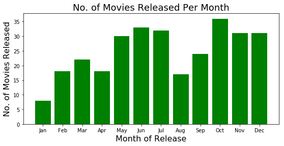

```python
# Import the required libraries to plot the graphs
import matplotlib, pylab
import matplotlib.pyplot as plt
%matplotlib inline

# Set the corresponding positions on the y-axis
y_pos = range(len(movieReleaseMonthDataFrame.index.values))

# Create a new figure & set the canvas size
plt.figure(figsize=(9,4))

# Plot the bar chart
bars = plt.bar(y_pos, movieReleaseMonthDataFrame['ReleaseMonth'], align='center', color='green')
plt.xticks(y_pos, movieReleaseMonthDataFrame.index.values)
plt.xlabel("Month of Release", fontsize=16)
plt.ylabel("No. of Movies Released", fontsize=16)
plt.title("No. of Movies Released Per Month", fontsize=18)
plt.show()
```

#### Distribution of 'Runtime' Feature across the Dataset

**This histogram plotted below, portrays the distribution of the attribute 'Runtime(mins)' using its frequencies across our dataset.**

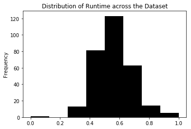

```python
obj = movieDetailsDataFrame["Runtime(mins)"].plot(kind="hist", title="Distribution of Runtime across the Dataset", bins=8, color='black')
```

#### Relationship between Popularity & Revenue

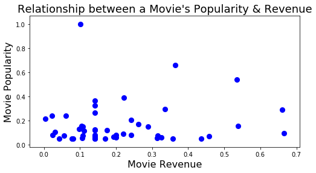

```python
# Create a new smaller dataframe containing the 'ReleaseDate', 'ReleaseMonth', 'ReleaseYear', 'Popularity' & 'Revenue($)'
moviePopularityRevenueDf = movieDetailsDataFrame[['Popularity', 'Revenue($)']]

# Sort the dataframe based on the column 'Popularity'
moviePopularityRevenueDf = moviePopularityRevenueDf.sort_values(by='Popularity', ascending=False)[0:50]

# Plot a line graph with the values
plt.figure(figsize=(8,4))
p = plt.scatter(moviePopularityRevenueDf['Revenue($)'], moviePopularityRevenueDf['Popularity'], color="blue", s=65)

# Set the labels for both the axes and also set the title of the graph
plt.xlabel('Movie Revenue', fontsize=16)
plt.ylabel('Movie Popularity', fontsize=16)
plt.title("Relationship between a Movie's Popularity & Revenue", fontsize=18)
```

#### Variations in Revenue and Vote Average across Months

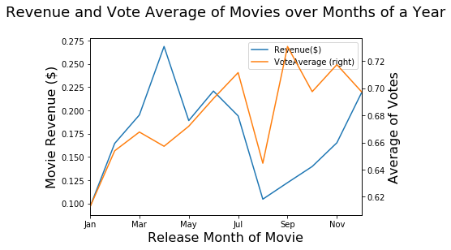

```python
# Create a smaller dataframe containing the mean revenue and vote average, grouped by the month of release
yearly_Group = movieDetailsDataFrame[['ReleaseMonth', 'Revenue($)', 'VoteAverage']].groupby('ReleaseMonth').agg('mean')
yearly_Group.index = pd.CategoricalIndex(yearly_Group.index, categories=uniqueMonthList, sorted=True)
yearly_Group = yearly_Group.sort_index()

# Plot a dual-axis graph representing how the mean revenue and vote average change with months
revVotePlt = yearly_Group.plot(secondary_y=['VoteAverage'])
revVotePlt.set_ylabel("Movie Revenue ($)", fontsize=16)
revVotePlt.set_xlabel("Release Month of Movie", fontsize=16)
revVotePlt.right_ax.set_ylabel("Average of Votes", fontsize=16)

plt.title("Revenue and Vote Average of Movies over Months of a Year\n", fontsize=18)
plt.show()
```

**The above graph can be split into sub-plots as shown below.**

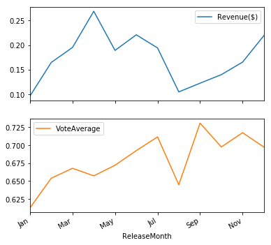

```python
yearly_Group.plot(subplots=True, figsize=(6, 6));
```

#### Revenue Distribution across Months, for every Year of Release

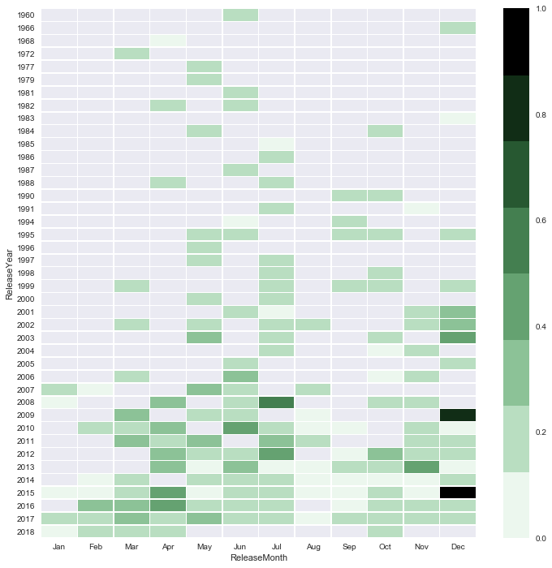

```python
import seaborn as sns
from matplotlib.colors import ListedColormap

# Create a copy of the main dataframe that contains only the columns 'ReleaseMonth', 'ReleaseYear','Revenue($)'
monthYearGroupDf = movieDetailsDataFrame[['ReleaseMonth', 'ReleaseYear','Revenue($)']].copy()
# Convert the columns 'ReleaseMonth' & 'ReleaseYear' to categorical variables
monthYearGroupDf['ReleaseMonth'] = pd.CategoricalIndex(monthYearGroupDf['ReleaseMonth'], categories=uniqueMonthList, sorted=True)
monthYearGroupDf['ReleaseYear'] = monthYearGroupDf['ReleaseYear'].astype('category')

# Plot a heatmap using seaborn
fig,ax = plt.subplots(figsize=(12,12))
my_cmap = ListedColormap(sns.cubehelix_palette(8, start=2, rot=0, dark=0, light=.95))
sns.heatmap(monthYearGroupDf.pivot_table(index='ReleaseYear', columns='ReleaseMonth', values='Revenue($)'),
            cmap=my_cmap, ax=ax, linewidth=0.5)
```

#### Popular Movies & their Directors, with Certification

Similar to the above plot, the below heatmap represents the popularity of movies directed by a director along with its certification.  
From the top *20* popular movies we selected from the dataframe, we see that the highest popularity was obtained for the movie directed by _James Foley_ which was certified/rated as _R_.

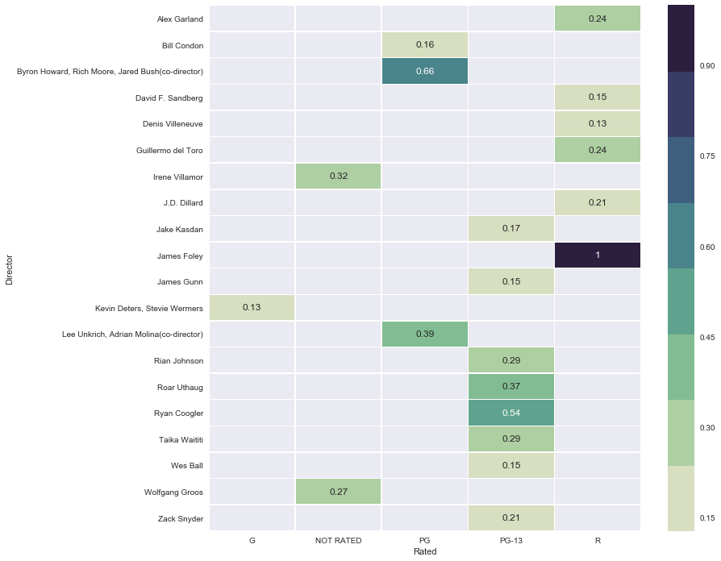

```python
# Create a copy of the main dataframe that contains only the columns 'ReleaseMonth', 'ReleaseYear','Revenue($)'
directorGroupDf = movieDetailsDataFrame[['Rated', 'Director', 'Popularity']].copy()
directorGroupDf = directorGroupDf.sort_values(by='Popularity', ascending=False)[0:20]

# Convert the columns 'ReleaseMonth' & 'ReleaseYear' to categorical variables
for ctg in ['Rated', 'Director']:
    directorGroupDf[ctg] = directorGroupDf[ctg].astype('category')

my_cmap = ListedColormap(sns.cubehelix_palette(8, start=.5, rot=-.75))
fig,ax = plt.subplots(figsize=(12,12))
sns.heatmap(directorGroupDf.pivot_table(index='Director', columns='Rated', values='Popularity'),
            cmap=my_cmap, ax=ax, linewidth=0.5, annot=True)
```

#### Connecting the Different Features in the Dataset

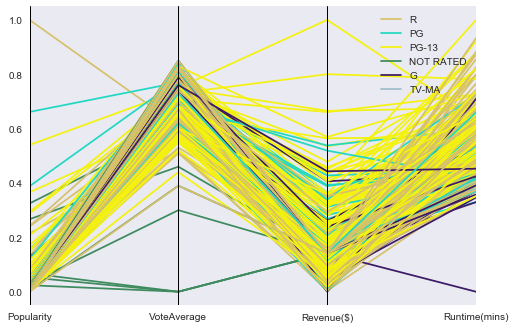

```python
# Copy the columns 'Popularity', 'VoteAverage', 'Revenue($)', 'Runtime(mins)' & 'Rated', to a new dataframe
tempDataFrame = movieDetailsDataFrame[['Popularity', 'VoteAverage', 'Revenue($)', 'Runtime(mins)', 'Rated']].copy()

# Plot the values using parallel co-ordinates
from pandas.plotting import parallel_coordinates
parCord = parallel_coordinates(tempDataFrame, "Rated")
```

#### No. of Movies Per Rating (Certification)

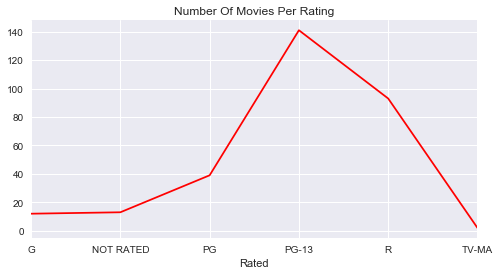

```python
ratedDataFrame = movieDetailsDataFrame[['MovieTitle', 'Rated']].copy()
ratedDataFrame = ratedDataFrame.groupby('Rated').count()

p = ratedDataFrame["MovieTitle"].plot(title="Number Of Movies Per Rating", figsize=(8,4), color='red')
```

## Conclusions Drawn

**In the above steps, we used multiple web-APIs to retrieve the data related to movies, parsed & combined them to a single CSV file, pre-processed the data and finally, created some visualizations based on our analysis.**

**Through a series of steps, we were able to analyze and understand the following:**

- **In which month of a year, the most number of movies are released.**
- **Identify the pattern of distribution of the runtime of a movie across our dataset.**
- **Nature of relationship between the Popularity & Revenue of a movie.**
- **How the Revenue and Average of Votes, vary across different months in a year.**
- **Identify the pattern of Revenue Distribution across different months, for every Year of Release.**
- **The top-20 Directors and Ratings for their movies, based on the Popularity of the movies.**
- **How the different attributes of our dataset are connected to each other, based on the Ratings(certifications) of the movies.**
- **The number of movies per Rating/Certification.**

**The point to note here is that, these conclusions are tentative and may be vary (or) remain same/smiliar when analyzed on huge datasets. At the moment, these results are based on 300 popular movies collected using multiple APIs.**

## Future Enhancements

One of the many possible future enhancements of this project, is extracting a random number of tweets about a movie from twitter, analyzing the tweet sentiment and using this polarity to calculate the popularity score of a movie. We can then compare the popularity score we obtained from IMDb with this score and do further analysis. We can also understand if the popularity of the movie comes in positive or negative contexts. We may also retrieve the movie reviews from IMDb for this purpose.  
In the belowsection, we try to gain an entry point to this enhancement.

### Sentiment Analysis of Movies using Tweets

**Here, we form a list of five most popular movies from our dataset (sorted based on their Popularity score) and extract ten random tweets from twitter, for each of them. We then try to determine the sentiment conveyed by each extracted tweet and plot pie-charts for each movie, depicting the share of different sentiments for it.**

```python
# Search Query parameters for Tweepy API
resultTypeParam = "mixed"
resultCount = 10

# The CSV file with the tweet data
movieTweetDataFileName = "17200802_Movie_Tweet_Data.csv"
headerList = ['MovieName','Id','TweetSentiment','RetweetCount','FavoriteCount']

# Create the CSV file with the headers
create_file(movieTweetDataFileName, headerList)

# List of movies to be searched for in Twitter, to get the tweets
tweetQueryList = (movieDetailsDataFrame.sort_values(by=['Popularity'], ascending=False)['MovieTitle'][0:5]).tolist()

# List of parameters to be retrieved for each tweet
tweetParamList = ['id', 'full_text', 'retweet_count', 'favorite_count']

# Iterate through the list of movies, extract the tweets & write the data to the CSV file
for query in tweetQueryList:
    tweetQueryResults = tw_api.search(q = query, lang = "en", result_type = resultTypeParam, count = resultCount,
                              include_entities = 'false', tweet_mode='extended')
    for status in tweetQueryResults['statuses']:
        getAndWriteTweetData(query, status, movieTweetDataFileName, tweetParamList)
        time.sleep(0.200)
```

```python
# Once the CSV is formed, load the data to a dataframe
movieTweetsDataFrame = pd.read_csv(movieTweetDataFileName, index_col='Id')
movieTweetsDataFrame[0:3]
```

| Id | MovieName | TweetSentiment | RetweetCount | FavoriteCount |
| --- | --- | --- | --- | --- |
| 974414022744461312 | Fifty Shades Freed | neutral | 84 | 364 |
| 976504486725324801 | Fifty Shades Freed | neutral | 30 | 61 |
| 978259548443037696 | Fifty Shades Freed | neutral | 0 | 0 |

**Now we try to visualize the distribution of sentiments collected from our tweets for each movie. Below, we have selected two random movies namely, _'Zootopia' & 'Coco'_ to create the visualizations. In large scale, we can either form charts for each movie or combine different movies to a single chart as required.**

```
array([<matplotlib.axes._subplots.AxesSubplot object at 0x0000024F4AD06C88>], dtype=object)
```

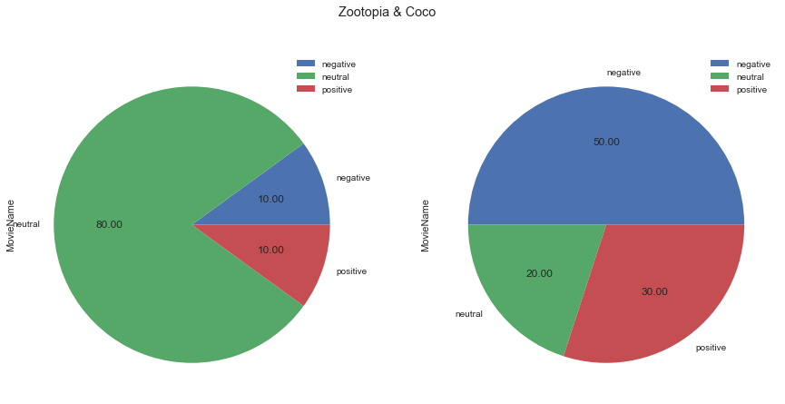

```python
# Create a dataframe for 'Zootopia' with its sentiment data
zootopiaDataFrame = movieTweetsDataFrame[["MovieName","TweetSentiment"]][movieTweetsDataFrame["MovieName"] == "Zootopia"].groupby("TweetSentiment").count()

# Create a dataframe for 'Coco' with its sentiment data
cocoDataFrame = movieTweetsDataFrame[["MovieName","TweetSentiment"]][movieTweetsDataFrame["MovieName"] == "Coco"].groupby("TweetSentiment").count()

# To print the two charts next to each other
fig, axs = plt.subplots(1,2, figsize=(15,7))

# Plot two pie charts for 'Zootopia' & 'Coco'
zootopiaDataFrame.plot(kind="pie", ax=axs[0], subplots=True, figsize =(4,4), legend=True, autopct='%.2f')
cocoDataFrame.plot(kind="pie", ax=axs[1], subplots=True, figsize =(4,4), legend=True, title="Zootopia & Coco", autopct='%.2f')
```

## References

1. **https://developers.themoviedb.org/3**
2. **http://www.omdbapi.com/**
3. **https://developer.twitter.com/en/docs/tweets/search/api-reference/get-search-tweets.html**
4. **http://docs.aylien.com/textapi/#using-the-api**
5. **https://pandas.pydata.org/pandas-docs/stable/**
6. **https://matplotlib.org/faq/usage_faq.html**
7. **https://seaborn.pydata.org/tutorial/color_palettes.html**
8. **https://seaborn.pydata.org/generated/seaborn.heatmap.html**
9. **COMP41680 - Lecture Slides, by Prof. Derek Greene**
10. **COMP41680 - Lab Tutorial Notebooks, by Prof. Derek Greene**